# MAGOLEGO SNA 2019 Egor Krotov HW #2

## Task 2. Flickr network

In the second task, you will work with a large directed graph. Please download flickr. matData contains sparse matrix A and list of user names. This is a denser part of the Flickr photo sharing sitefriendship graph from 2006. Edge direction corresponds to friendship requests (following). Some of the linksare reciprocal, others not It’s a Matlab file. How to deal with it in R? There is a packageR.matlab. Please install it and calllibrary(R.matlab) Now use readMat function to read the file and extract adjacency matrix and a list of user names:

```r
flickr = readMat("flickr.mat")
flickr.mat = as.matrix(flickr[1]$A)
flickr.names = flickr[2]$names
```

If you have trouble loading large mat file on your laptop — try to use HSE computer classes with installed R+RStudio. Look at user names. You might want to remove spaces from the names. Use a functiongsubto remove them:

```r
flickr.names = gsub(" ", "", flickr.names)
```

Now create a graph, output the number of vertices and edges:

```r
flickr_graph = graph.adjacency(flickr.mat, mode = "directed", weighted = NULL)
flickr_names = flickr.names
print("Vertices and Edges :")
```

```
## [1] "Vertices and Edges :"
```

```r
vcount(flickr_graph)
```

```
## [1] 15724
```

```r
ecount(flickr_graph)
```

```
## [1] 510983
```

Compute in- and out- degree centralities, PageRank, Hubs and Authorities for this network:

```r
in_degree = centralization.degree(flickr_graph, mode = "in")$centralization
out_degree = centralization.degree(flickr_graph, mode = "out")$centralization
pagerank =  page.rank(flickr_graph)$vector
hubs = hub.score(flickr_graph)$vector
auth = authority.score(flickr_graph)$vector
```

Print top ten names in each ranking:

```r
print("In-degree:")
```

```
## [1] "In-degree:"
```

```r
in_degree<-degree(flickr_graph, mode = "in")
top_in <- sort(in_degree, decreasing = TRUE)[1:10]
flickr.names[which(in_degree %in% top_in)]
```

```
##  [1] "notraces"         "awfulsara"        "DrJoanne"
##  [4] "drp"              "BombDog"          ":Nikola"
##  [7] "*Ivan*"           "deborahlattimore" "SimonPais"
## [10] "antimethod"       "MaDGi®L•\231"
```

```r
make_space()
```

```
## [1] " _____________________ "
```

```r
print("Out-degree:")
```

```
## [1] "Out-degree:"
```

```r
out_degree=degree(flickr_graph, mode = "out")
top_out <- sort(out_degree, decreasing = TRUE)[1:10]
flickr.names[which(out_degree %in% top_out)]
```

```
##  [1] "anildash"      "maximolly"     "jakedobkin"    "brainware3000"
##  [5] "Jakes_World"   "Buntekuh"      "pixietart"     "tozzer"
##  [9] "AtiRanA"       "AndreiaLopes"
```

```r
make_space()
```

```
## [1] " _____________________ "
```

```r
print("Page Rank:")
```

```
## [1] "Page Rank:"
```

```r
top_pr <- sort(pagerank, decreasing = TRUE)[1:10]
flickr.names[which(pagerank %in% top_pr)]
```

```
##  [1] "awfulsara"        "DrJoanne"         "drp"
##  [4] "BombDog"          "cymagen"          "*Ivan*"
##  [7] "deborahlattimore" "SimonPais"        "antimethod"
## [10] "MaDGi®L•\231"
```

```r
make_space()
```

```
## [1] " _____________________ "
```

```r
print("Hubs:")
```

```
## [1] "Hubs:"
```

```r
top_hub <- sort(hubs, decreasing = TRUE)[1:10]
flickr.names[which(hubs %in% top_hub)]
```

```
##  [1] "mrpiink"     "noahstone"   "isherwood"   "sgoralnick"  "*starlet*"
##  [6] "automat"     "brynfoto"    "liquidpixel" "lorrainemd"  "schizoo23"
```

```r
make_space()
```

```
## [1] " _____________________ "
```

```r
print("Authorities:")
```

```
## [1] "Authorities:"
```

```r
top_auth <- sort(auth, decreasing = TRUE)[1:10]
flickr.names[which(auth %in% top_auth)]
```

```
##  [1] "awfulsara"        "DrJoanne"         "drp"
##  [4] "BombDog"          ":Nikola"          "cymagen"
##  [7] "*Ivan*"           "deborahlattimore" "SimonPais"
## [10] "antimethod"
```

Produce the following plots: * In-degree centralities versus out-degree centralities * In-degree centralities versus authorities * Out-degree centralities versus hubs * Hubs versus authorities * PageRank versus hubs * PageRank versus authorities

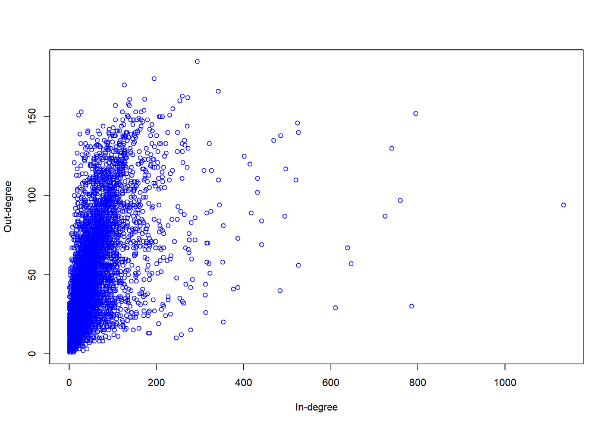

```r
plot(in_degree, out_degree, col="blue", xlab = "In-degree", ylab = "Out-degree")
```

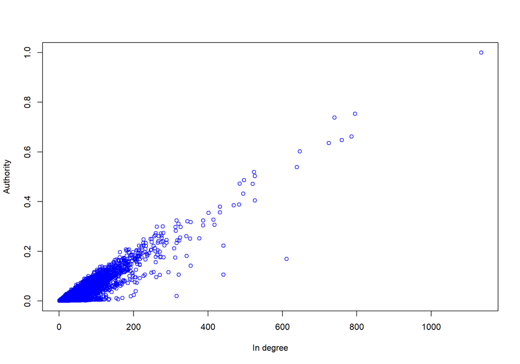

```r
plot(in_degree, auth, col="blue", xlab = "In degree", ylab = "Authority")
```